# Project 2: Data Mining, Classification, Prediction

SDS322E

# Mining, Classification, Prediction

## Chu Nie cn9863

### Introduction

The data set contains the data we need for a simple customer personality behavior analysis. The dataset contains 29 variables and 2216 observations in total (after dropping the NAs). After cleaning the dataset, there are 25 variables.The main variable that I use for the project is Recency,Year_Birth, Income, Res, and several variables that present the number of times that the customer made purchasements. Recency is the number of days since customer’s last purchase. The Year_Birth is the customer’s birth year. Income gives us the customer’s yearly household income. If Res equals to 1, the customer accepted the offer in the campaign, 0 otherwise.(The binary variable) Response is the number of times that a customer respond to the offer.NumWebPurchases: Number of purchases made through the company’s website. NumCatalogPurchases: Number of purchases made using a catalogue.NumStorePurchases: Number of purchases made directly in stores.NumWebVisitsMonth: Number of visits to company’s website in the last month.

```r
library(tidyverse)
library(readr)
library(dplyr)
# read your datasets in here, e.g., with read_csv()
data <- read.csv("marketing_campaign.csv", sep = "\t")

data <- data %>% na.omit()

data <- data %>% mutate(Response = Response + AcceptedCmp1 +
    AcceptedCmp2 + AcceptedCmp3 + AcceptedCmp4 + AcceptedCmp5) %>%
    mutate(Res = if_else(Response != 0, 1, 0)) %>% select(-c(AcceptedCmp1,
    AcceptedCmp2, AcceptedCmp3, AcceptedCmp4, AcceptedCmp5))

head(data)
```

```
##     ID Year_Birth  Education Marital_Status Income Kidhome Teenhome Dt_Customer
## 1 5524       1957 Graduation         Single  58138       0        0  04-09-2012
## 2 2174       1954 Graduation         Single  46344       1        1  08-03-2014
## 3 4141       1965 Graduation       Together  71613       0        0  21-08-2013
## 4 6182       1984 Graduation       Together  26646       1        0  10-02-2014
##   Recency MntWines MntFruits MntMeatProducts MntFishProducts MntSweetProducts
## 1      58      635        88             546             172               88
## 2      38       11         1               6               2                1
## 3      26      426        49             127             111               21
## 4      26       11         4              20              10                3
##   MntGoldProds NumDealsPurchases NumWebPurchases NumCatalogPurchases
## 1           88                 3               8                  10
## 2            6                 2               1                   1
## 3           42                 1               8                   2
## 4            5                 2               2                   0
##   NumStorePurchases NumWebVisitsMonth Complain Z_CostContact Z_Revenue Response
## 1                 4                 7        0             3        11        1
## 2                 2                 5        0             3        11        0
## 3                10                 4        0             3        11        0
## 4                 4                 6        0             3        11        0
##   Res
## 1   1
## 2   0
## 3   0
## 4   0
##  [ reached 'max' / getOption("max.print") -- omitted 2 rows ]
```

### Cluster Analysis

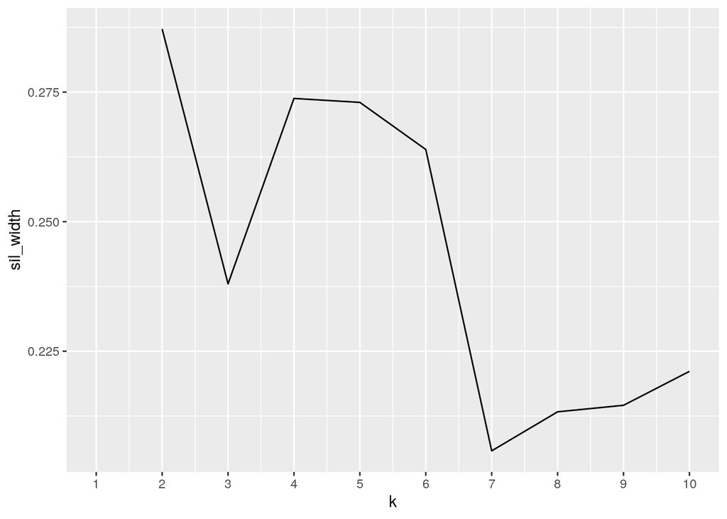

```r
library(cluster)
library(GGally)
# clustering code here
pam_dat <- data %>% select(Recency, NumDealsPurchases, NumWebPurchases,
    NumStorePurchases) %>% scale

sil_width <- vector()
for (i in 2:10) {
    pam_fit <- pam(pam_dat, k = i)
    sil_width[i] <- pam_fit$silinfo$avg.width
}
ggplot() + geom_line(aes(x = 1:10, y = sil_width)) + scale_x_continuous(name = "k",
    breaks = 1:10)
```

```r
pam1 <- pam_dat %>% pam(k = 2)
pam1
```

```
## Medoids:
##        ID    Recency NumDealsPurchases NumWebPurchases NumStorePurchases
## [1,] 1918  0.0341078        -0.1681932       0.6985572         0.9840723
## [2,] 1701 -0.1040693        -0.1681932      -0.7607902        -0.8616359
## Clustering vector:
##   [1] 1 2 1 2 1 1 1 2 2 2 2 1 1 2 1 2 2 1 2 2 2 1 1 1 2 2 2 1 2 2 2 2 1 2 1 2 2
##  [38] 1 1 2 2 2 1 2 2 1 1 1 2 1 1 1 1 2 1 1 1 1 1 1 2 2 1 1 2 2 1 1 2 2 1 1 2 1
##  [75] 2 2 2 2 1 2 2 1 1 2 2 2 2 1 2 1 1 2 2 1 1 2 2 2 1 2
##  [ reached getOption("max.print") -- omitted 2116 entries ]
## Objective function:
##    build     swap
## 1.631457 1.531635
##
## Available components:
##  [1] "medoids"    "id.med"     "clustering" "objective"  "isolation"
##  [6] "clusinfo"   "silinfo"    "diss"       "call"       "data"
```

```r
pamclust <- data %>% mutate(cluster = as.factor(pam1$clustering))
pamclust
```

```
##     ID Year_Birth  Education Marital_Status Income Kidhome Teenhome Dt_Customer
## 1 5524       1957 Graduation         Single  58138       0        0  04-09-2012
## 2 2174       1954 Graduation         Single  46344       1        1  08-03-2014
## 3 4141       1965 Graduation       Together  71613       0        0  21-08-2013
##   Recency MntWines MntFruits MntMeatProducts MntFishProducts MntSweetProducts
## 1      58      635        88             546             172               88
## 2      38       11         1               6               2                1
## 3      26      426        49             127             111               21
##   MntGoldProds NumDealsPurchases NumWebPurchases NumCatalogPurchases
## 1           88                 3               8                  10
## 2            6                 2               1                   1
## 3           42                 1               8                   2
##   NumStorePurchases NumWebVisitsMonth Complain Z_CostContact Z_Revenue Response
## 1                 4                 7        0             3        11        1
## 2                 2                 5        0             3        11        0
## 3                10                 4        0             3        11        0
##   Res cluster
## 1   1       1
## 2   0       2
## 3   0       1
##  [ reached 'max' / getOption("max.print") -- omitted 2213 rows ]
```

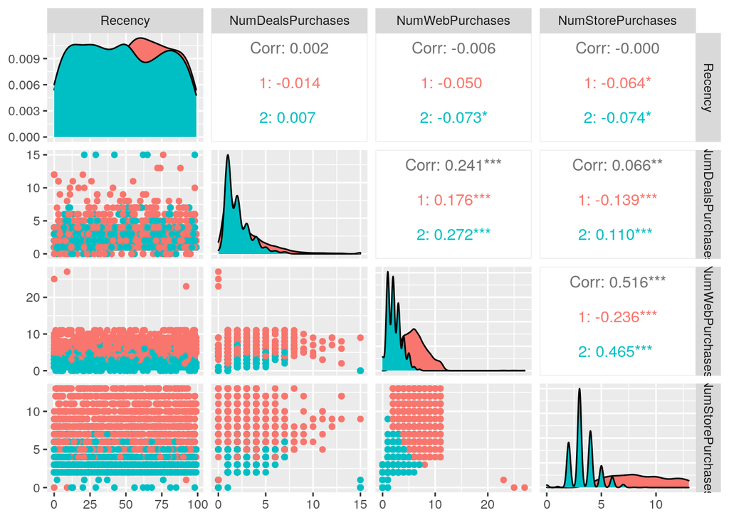

```r
pamclust %>% ggpairs(col = c("Recency", "NumDealsPurchases",
    "NumWebPurchases", "NumStorePurchases"), aes(color = cluster))
```

### Dimensionality Reduction with PCA

```r
# PCA code here
library(ggplot2)
d1 <- data %>% select(Recency, Kidhome, Teenhome, MntWines, MntFruits,
    MntMeatProducts, MntFishProducts, MntSweetProducts, MntGoldProds,
    NumDealsPurchases, NumWebPurchases, NumStorePurchases, NumCatalogPurchases,
    NumWebVisitsMonth) %>% scale
pca_1 <- princomp(d1, cor = T)
summary(pca_1, loadings = T)
```

```
## Importance of components:
##                           Comp.1    Comp.2     Comp.3     Comp.4     Comp.5
## Standard deviation     2.3572675 1.3560728 1.00232350 0.98605231 0.87414302
## Proportion of Variance 0.3969079 0.1313524 0.07176089 0.06944994 0.05458043
## Cumulative Proportion  0.3969079 0.5282602 0.60002113 0.66947107 0.72405150
##                            Comp.6     Comp.7     Comp.8     Comp.9   Comp.10
## Standard deviation     0.85266752 0.79763865 0.68673362 0.65349081 0.6313896
## Proportion of Variance 0.05193156 0.04544482 0.03368593 0.03050359 0.0284752
## Cumulative Proportion  0.77598306 0.82142788 0.85511381 0.88561740 0.9140926
##                           Comp.11    Comp.12    Comp.13    Comp.14
## Standard deviation     0.62541078 0.58796986 0.49521156 0.46970402
## Proportion of Variance 0.02793847 0.02469347 0.01751675 0.01575871
## Cumulative Proportion  0.94203108 0.96672455 0.98424129 1.00000000
##
## Loadings:
##                     Comp.1 Comp.2 Comp.3 Comp.4 Comp.5 Comp.6 Comp.7 Comp.8
## Recency                            0.993
## Kidhome             -0.285               -0.498        -0.305         0.377
## Teenhome                    0.506         0.408 -0.542 -0.190        -0.192
## MntWines             0.315  0.207         0.156  0.444
## MntFruits            0.305 -0.111        -0.269 -0.325         0.208
## MntMeatProducts      0.341 -0.123                0.252 -0.336 -0.127 -0.223
## MntFishProducts      0.316 -0.128        -0.268 -0.266
##                     Comp.9 Comp.10 Comp.11 Comp.12 Comp.13 Comp.14
## Recency
## Kidhome                    -0.463  -0.432                   0.130
## Teenhome                   -0.240  -0.303  -0.105  -0.169
## MntWines                   -0.248  -0.268  -0.435   0.287  -0.457
## MntFruits            0.715 -0.262   0.261           0.134
## MntMeatProducts                                    -0.758  -0.153
## MntFishProducts             0.579  -0.622
##  [ reached getOption("max.print") -- omitted 7 rows ]
```

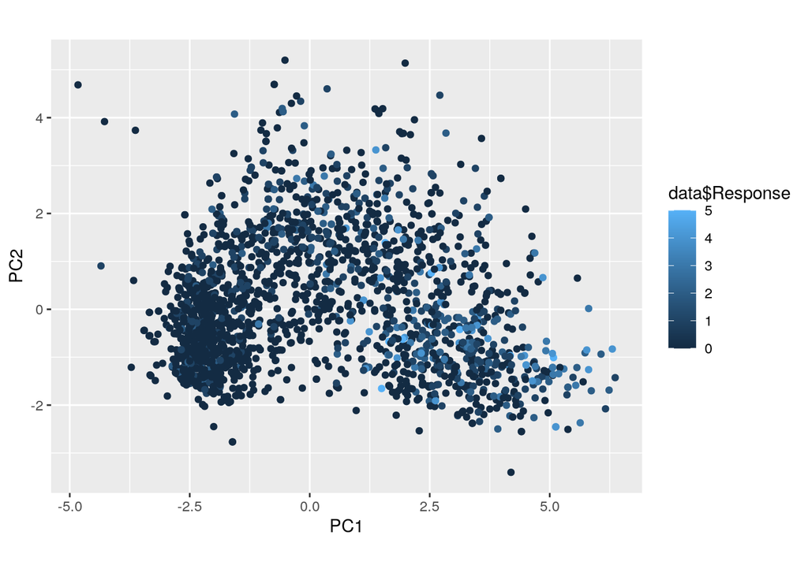

```r
data %>% mutate(PC1 = pca_1$scores[, 1], PC2 = pca_1$scores[,
    2]) %>% ggplot(aes(PC1, PC2)) + geom_point(aes(color = data$Response)) +
    coord_fixed()
```

PC1:the higher the MntWines/MntFruits/MntMeatProducts/MntFishProducts, the less likely the customer has kid home. PC2: The higher the Teenhome and MntWines the less likely the customer purchases fruit, meat and fish. PC3: Recency is the only variable affect the pc3. PC4: The Kidhome, MntFruits and MntFishProduct have negatively affect the PC4. PC5: Teenhome, MntFruits and MntFishProduct have negatively affect the PC5. It takes 5 principle components to represent 72.4%.

### Linear Classifier

```r
# linear classifier code here
fit <- glm(Res ~ Income + Kidhome + Teenhome + Recency + NumDealsPurchases +
    NumWebPurchases + NumCatalogPurchases + NumWebVisitsMonth +
    Complain + Year_Birth, data = data, family = "binomial")

score <- predict(fit, type = "response")
# score %>% round(3)

class_diag <- function(score, truth, positive, cutoff = 0.5,
    strictlygreater = T) {
    if (strictlygreater == T)
        pred <- factor(score > cutoff, levels = c("TRUE", "FALSE")) else pred <- factor(score >= cutoff, levels = c("TRUE", "FALSE"))
    truth <- factor(truth == positive, levels = c("TRUE", "FALSE"))
    tab <- table(truth, pred)
    acc = sum(diag(tab))/sum(tab)
    sens = tab[1, 1]/rowSums(tab)[1]
    spec = tab[2, 2]/rowSums(tab)[2]
    ppv = tab[1, 1]/colSums(tab)[1]
    # CALCULATE F1
    f1 = 2 * (sens * ppv)/(sens + ppv)
    # CALCULATE EXACT AUC
    truth <- as.numeric(truth == "TRUE")
    ord <- order(score, decreasing = TRUE)
    score <- score[ord]
    truth <- truth[ord]
    TPR = cumsum(truth)/max(1, sum(truth))
    FPR = cumsum(!truth)/max(1, sum(!truth))
    dup <- c(score[-1] >= score[-length(score)], FALSE)
    TPR <- c(0, TPR[!dup], 1)
    FPR <- c(0, FPR[!dup], 1)
    n <- length(TPR)
    auc <- sum(((TPR[-1] + TPR[-n])/2) * (FPR[-1] - FPR[-n]))
    round(data.frame(acc, sens, spec, ppv, f1, ba = (sens + spec)/2,
        auc, row.names = "Metrics"), 4)
}

class_diag(score, data$Res, positive = 1)
```

```
##            acc   sens   spec    ppv     f1     ba    auc
## Metrics 0.7671 0.3207 0.9348 0.6488 0.4292 0.6277 0.7627
```

```r
table(truth = factor(data$Res == 1, levels = c("TRUE", "FALSE")),
    prediction = factor(score > 0.5, levels = c("TRUE", "FALSE")))
```

```
##        prediction
## truth   TRUE FALSE
##   TRUE   194   411
##   FALSE  105  1506
```

```r
# cross-validation of linear classifier here
set.seed(1234)
k = 10
temp <- data[sample(nrow(data)), ]
folds <- cut(seq(1:nrow(temp)), breaks = k, labels = F)
diags <- NULL
for (i in 1:k) {
    train <- temp[folds != i, ]
    test <- temp[folds == i, ]
    truth <- test$Res
    fit <- glm(Res ~ Income + Kidhome + Teenhome + Recency +
        NumDealsPurchases + NumWebPurchases + NumCatalogPurchases +
        NumWebVisitsMonth + Complain + Year_Birth, data = train,
        family = "binomial")
    probs <- predict(fit, newdata = test, type = "response")
    diags <- rbind(diags, class_diag(probs, truth, positive = 1))
}

summarize_all(diags, mean)
```

```
##       acc   sens    spec     ppv      f1      ba     auc
## 1 0.76354 0.3146 0.93221 0.63258 0.41807 0.62341 0.75426
```

### Non-Parametric Classifier

```r
library(caret)
# non-parametric classifier code here
knn_fit <- knn3(factor(Res == 1, levels = c("TRUE", "FALSE")) ~
    Income + Kidhome + Teenhome + Recency + NumDealsPurchases +
        NumWebPurchases + NumCatalogPurchases + NumWebVisitsMonth +
        Complain + Year_Birth, data = data, k = 5)

knn1 <- predict(knn_fit, data)
knn1
```

```
##              TRUE     FALSE
##    [1,] 0.2000000 0.8000000
##    [2,] 0.2000000 0.8000000
##    [3,] 0.8000000 0.2000000
##    [4,] 0.2000000 0.8000000
##    [5,] 0.0000000 1.0000000
##    [6,] 0.2000000 0.8000000
##    [7,] 0.6000000 0.4000000
##    [8,] 0.0000000 1.0000000
##    [9,] 0.2000000 0.8000000
##   [10,] 0.2000000 0.8000000
##   [11,] 0.0000000 1.0000000
##   [12,] 0.2000000 0.8000000
##   [13,] 0.0000000 1.0000000
##   [14,] 0.4000000 0.6000000
```

[output cut: 37 more lines]

```r
class_diag(knn1[, 1], data$Res, positive = 1)
```

```
##            acc   sens   spec    ppv     f1     ba    auc
## Metrics 0.8127 0.5289 0.9193 0.7111 0.6066 0.7241 0.8585
```

```r
table(truth = factor(data$Res == 1, levels = c("TRUE", "FALSE")),
    prediction = factor(knn1[, 1] > 0.5, levels = c("TRUE", "FALSE")))
```

```
##        prediction
## truth   TRUE FALSE
##   TRUE   320   285
##   FALSE  130  1481
```

```r
# cross-validation of np classifier here
set.seed(1234)
k = 10
temp <- data[sample(nrow(data)), ]
folds <- cut(seq(1:nrow(temp)), breaks = k, labels = F)
diags <- NULL
for (i in 1:k) {
    train <- temp[folds != i, ]
    test <- temp[folds == i, ]
    truth <- test$Res
    fit <- knn3(Res ~ Income + Kidhome + Teenhome + Recency +
        NumDealsPurchases + NumWebPurchases + NumCatalogPurchases +
        NumWebVisitsMonth + Complain + Year_Birth, data = train)
    probs <- predict(fit, newdata = test)[, 2]
    diags <- rbind(diags, class_diag(probs, truth, positive = 1))
}

summarize_all(diags, mean)
```

```
##       acc   sens    spec     ppv      f1      ba     auc
## 1 0.72695 0.3369 0.87339 0.50728 0.40261 0.60515 0.68712
```

By performing KNN, we get the AUC of 0.8585. However, when doing the cross-validation, we get AUC of 0.68712. The AUC decreases. Thus, there is moderate overfitting in this model.

### Regression/Numeric Prediction

```r
# regression model code here
data1 <- data %>% select(-Dt_Customer)
reg1 <- lm(Res ~ ., data = data1)

reg1_sum <- summary(reg1)

mse <- mean(reg1_sum$residuals^2)

mse
```

```
## [1] 0.06281474
```

```r
# cross-validation of regression model here
set.seed(1234)
k = 5
data1 <- data %>% select(-Dt_Customer)
temp <- data1[sample(nrow(data1)), ]
folds <- cut(seq(1:nrow(data1)), breaks = k, labels = F)
diags <- NULL
for (i in 1:k) {
    train <- temp[folds != i, ]
    test <- temp[folds == i, ]
    fit <- lm(Res ~ ., data = train)
    yhat <- predict(fit, newdata = test)
    diags <- mean((test$Res - yhat)^2)
}
mean(diags)
```

```
## [1] 0.07616929
```

By performing the linear regression model, we get the MSE of 0.06281474, indicating the model yields a good prediction. In cross-validation, we get the MSE of 0.07616929. Thus, there is no overfitting in this model.The model give us a good prediction on whether the customer would respond to the campaign.

### Python

```r
library(reticulate)
use_python("/usr/bin/python3", required = F)
income <- data$Income
```

```python
# python code here
a = max(r.income)
b = min(r.income)
print(min(r.income),max(r.income))
```

```
## 1730 666666
```

```python
print(max(r.income)-min(r.income))
```

```
## 664936
```

```r
py$b
```

```
## [1] 1730
```

```r
py$a
```

```
## [1] 666666
```

```r
py$a - py$b
```

```
## [1] 664936
```

Comparing the maximum income, minimum income, and the difference between in both python and R.